# Matrix Completion vs Difference-in-Differences on the Callaway–Sant’Anna Minimum-Wage Data

Replication package — state-cluster bootstrap inference

Marco Ventura, Angela Zanoni

# 1 Overview

Replication package for *“Understanding Matrix Completion for Causal Panel Data. A Practitioner’s Guide with an Application to the Employment Effects of Minimum Wage”*.

MCP estimates use the MCPanel package. The document follows the order of the paper:

1. **Low-rank diagnostic** — scree plot of the singular values of the masked outcome matrix $Y_\text{obs}$ (Figure 1; Section 3.2 of the paper).
2. **Unconditional case** — MCP without covariates (`MCPanel::mcnnm_cv`) compared against the Callaway–Sant’Anna staggered DiD, for both control groups: not-yet-treated (benchmark, Table A.4) and never-treated (Table A.5); group-time plots as in Figures A.2 and A.4.
3. **Conditional case** — MCP with covariates (`MCPanel::mcnnm_wc_cv`) against the covariate-adjusted CS estimator, again for both control groups (Tables 2 and A.3; Figures A.1 and A.3).
4. **Implementation details** — software versions, the $\lambda$ grids and cross-validation design, selected regularization parameters, bootstrap settings, and the effective rank of $\hat L$.
5. **Parallel-trends falsification** — the specification tests of Section 4 (Tables 3 and A.6).

**Inference for MCP.** Standard errors and 95% confidence intervals for MCP come from a **state-cluster bootstrap**: treated counties are kept fixed, never-treated states are resampled with replacement, and MCP is refitted at the full-sample $\lambda$. This replaces the non-clustered descriptive standard errors $sd_{g,t}/\sqrt{n_{g,t}}$ of Appendix A.2. Point estimates are those of the full-sample fit.

The sensitivity analyses of Appendix A.7 (Tables A.7–A.9) are implemented in the companion document `sensitivity.Rmd` distributed with this package.

## 1.1 Required inputs

Place in the `data/` folder next to this document:

- `data/df_covs_linear.csv` — CS minimum-wage panel with linearly-interpolated time-varying covariates (US Census intercensal datasets and SAIPE; see Appendix A.3 of the paper), and a `state_name` column used as the bootstrap cluster.

## 1.2 Required packages

`MCPanel`, `did`, `dplyr`, `tidyr`, `readr`, `ggplot2`, `knitr`. `MCPanel` is not on CRAN:

```r
# install.packages("devtools")
devtools::install_github("susanathey/MCPanel@6b2706fd7c35f3266048ceb22a7e9a61ae1774da")   # commit used for the paper
```

```r
suppressPackageStartupMessages({
  library(dplyr); library(tidyr); library(readr); library(ggplot2)
  library(MCPanel)  # matrix completion
  library(did)      # Callaway-Sant'Anna
  library(knitr)
})

SEED    <- 2024
B       <- 200     # bootstrap replications
ALPHA   <- 0.05    # 95% percentile intervals
N_CORES <- max(1L, min(3L, parallel::detectCores() - 1L))   # MCP-C needs ~8-10 GB RAM per core
set.seed(SEED)
```

# 2 Data

```r
# Load data
cov_vars <- c("pop_covs", "white_covs", "pov_covs", "medinc_covs")

df <- readr::read_csv("data/df_covs_linear.csv", show_col_types = FALSE)

# Sort counties in descending order by first treatment year: treated block on top, never-treated last
unit_order <- df |>
  distinct(countyreal, firsttreat) |>
  arrange(desc(firsttreat), countyreal) |>
  pull(countyreal)
```

## 2.1 Comparison of covariates (pre-treatment year)

Sanity check replicating Table A.2 of the paper: our reconstructed county covariates in the last pre-treatment year against those distributed with the original CS dataset.

```r
# Filter data to pre-treatment year for the treated
pre <- df |>
  filter(year == firsttreat - 1, treat == 1) |>
  drop_na(all_of(cov_vars))

# Build table
comparison <- tibble::tibble(
  variable    = c("log(pop)", "white share", "median income (1000s)", "poverty rate"),
  `CS`        = c(mean(pre$pop,    na.rm = TRUE),
                  mean(pre$white,  na.rm = TRUE),
                  mean(pre$medinc, na.rm = TRUE),
                  mean(pre$pov,    na.rm = TRUE)),
  `Our Panel` = c(mean(pre$pop_covs,    na.rm = TRUE),
                  mean(pre$white_covs,  na.rm = TRUE),
                  mean(pre$medinc_covs, na.rm = TRUE),
                  mean(pre$pov_covs,    na.rm = TRUE))
)
knitr::kable(comparison, digits = 3,
             caption = "Mean of covariates, comparison with the original CS dataset (paper Table A.2)")
```

Mean of covariates, comparison with the original CS dataset (paper Table A.2)

| variable | CS | Our Panel |
| --- | --- | --- |
| log(pop) | 3.537 | 3.590 |
| white share | 0.893 | 0.897 |
| median income (1000s) | 33.909 | 40.735 |
| poverty rate | 0.131 | 0.127 |

## 2.2 From long panel to MCPanel matrices

`MCPanel` requires $N \times T$ matrices: the outcome $Y$ and a mask, equal to 1 where the entry is observed (untreated) and 0 where the counterfactual must be imputed (treated unit–time pairs), i.e. `mask = 1 - treat_mat`. Units are ordered by descending treatment cohort so that treated units occupy the first rows, as in the original scripts.

When covariates are requested, the function also returns the $N \times P$ matrix $X$ of unit-specific covariate means and the $T \times Q$ matrix $Z$ of time-specific covariate means, which is how `mcnnm_wc` accommodates the $XHZ'$ structure (see Section 2.1 of the paper).

The function also keeps the state of each county, which is the cluster resampled by the bootstrap.

```r
build_panel_matrices <- function(df, cov_names = NULL) {

  df <- df |>
    mutate(
      t_group = as.integer(year >= firsttreat),
      t       = treat * t_group
    )

  # Restrict the global unit_order to units actually present in this df
  local_unit_order <- unit_order[unit_order %in% unique(df$countyreal)]

  to_wide <- function(varname) {
    df |>
      select(countyreal, year, all_of(varname)) |>
      pivot_wider(names_from  = year,
                  values_from = all_of(varname),
                  values_fn   = ~ mean(.x, na.rm = TRUE)) |>
      arrange(match(countyreal, local_unit_order)) |>
      select(-countyreal) |>
      mutate(across(everything(), as.numeric)) |>
      as.matrix()
  }

  Y     <- to_wide("lemp")
  treat <- to_wide("t")
  mask  <- 1 - treat

  first_treat <- df |>
    distinct(countyreal, firsttreat) |>
    arrange(match(countyreal, local_unit_order)) |>
    pull(firsttreat)

  # State of each row: cluster for the bootstrap
  state <- df |>
    distinct(countyreal, state_name) |>
    arrange(match(countyreal, local_unit_order)) |>
    pull(state_name)

  out <- list(Y = Y, mask = mask, treat_mat = treat,
              unit_order  = local_unit_order,
              first_treat = first_treat,
              state       = state,
              years       = as.integer(colnames(Y)))

  if (!is.null(cov_names)) {
    out$X <- df |>
      group_by(countyreal) |>
      summarise(across(all_of(cov_names), \(x) mean(x, na.rm = TRUE)),
                .groups = "drop") |>
      arrange(match(countyreal, local_unit_order)) |>
      select(-countyreal) |>
      as.matrix()

    out$Z <- df |>
      group_by(year) |>
      summarise(across(all_of(cov_names), \(x) mean(x, na.rm = TRUE)),
                .groups = "drop") |>
      arrange(year) |>
      select(-year) |>
      as.matrix()
  }

  out
}

mats <- build_panel_matrices(df)
```

# 3 Diagnostic: scree plot on the masked outcome matrix

Following Section 3.2 of the paper, we assess the plausibility of the low-rank assumption on $Y_\text{obs}$, the outcome matrix with post-treatment cells of treated units masked, so that the SVD is not contaminated by treatment effects.

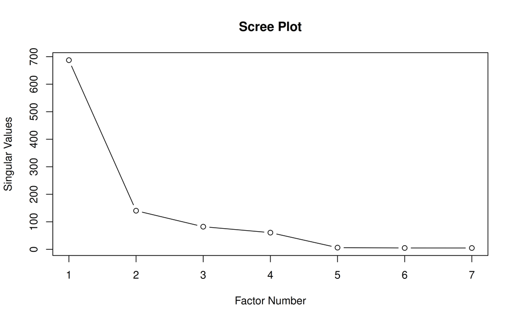

Scree plot of the singular values of $Y_\text{obs}$ (paper Figure 1).

```r
Y_obs <- mats$Y * mats$mask     # mask (set to 0) post-treatment cells of treated units

sv <- svd(Y_obs)
s <- sv$d     # get singular values

plot(s, type = "b", main = "Scree Plot",
     ylab = "Singular Values", xlab = "Factor Number")
```

```r
# Variance share of a singular value: sigma_k^2 / sum(sigma^2)
share_first <- s[1]^2 / sum(s^2)
sprintf("Variance share of the first singular value: %.1f%%", 100 * share_first)
```

```
## [1] "Variance share of the first singular value: 94.0%"
```

The plot shows a pronounced drop from $\sigma_1$ to $\sigma_2$ and near-zero values from $\sigma_5$ onwards: an effectively rank-four structure. Under strict parallel trends the counterfactual matrix would have rank at most two (unit plus time fixed effects); four non-negligible singular values exceed that signature and motivate an estimator accommodating interactive factor structure (see the discussion of Figure 1 in the paper).

In order to give a concrete interpretation to the low-rank structure recovered, one could look into the correlation between covariates and L.

```r
# Inspect correlation between singular values and covariates
# This allows to interpret the nature of the retrieved low-rank structure

# Varimax rotation to univocally identify factors


K=4     # Set a number of factors according to the scree plot

Gamma_hat <- sv$u[, 1:K, drop = FALSE] %*% diag(sqrt(s[1:K]), K)    # extract unit-specific factor loadings
colnames(Gamma_hat) <- paste0("gamma_", 1:K)

cov_vars <- c("pop_covs", "white_covs", "pov_covs", "medinc_covs")

unit_covs <- df %>%
  group_by(countyreal) %>%
  summarise(across(all_of(cov_vars), \(x) mean(x, na.rm = TRUE)),
            .groups = "drop") %>%
  arrange(match(countyreal, unit_order))

print(round(cor(Gamma_hat, unit_covs[cov_vars],
                use = "pairwise.complete.obs"), 3))
```

```
##         pop_covs white_covs pov_covs medinc_covs
## gamma_1   -0.769      0.284    0.010      -0.362
## gamma_2    0.176      0.107   -0.164       0.134
## gamma_3   -0.024      0.044   -0.074       0.038
## gamma_4   -0.012      0.007    0.025       0.002
```

# 4 Unconditional case

## 4.1 MCP estimation (no covariates)

The MCP fit is common to both control-group comparisons: the estimator uses all untreated cells regardless of how the DiD benchmark defines its controls. `msk_err` is the gap between fitted and observed outcome, kept on treated cells only: minus `msk_err` is the individual treatment effect.

The estimation needs three building blocks, defined once and reused in the conditional case: the aggregation of individual effects into ATTs, the bootstrap summary, and the MCP fit with its bootstrap.

### 4.1.1 From imputation errors to ATTs

Cohort-year ATTs from the treated-cell errors, with the same aggregations as the paper: cohort-specific effects (mean over post-treatment years within cohort) and event-study effects (mean over cohorts at each event time). These functions return point estimates only; their uncertainty comes from re-running them on every bootstrap sample.

```r
# Compute cohort-year ATT table from the matrix of imputation errors
## Recall that MCP estimates the counterfactual quantities by imputing the "holes" in Y_obs
## Then the difference between imputed and observed cells gives the treatment effect

compute_att_table <- function(effect_mat, years, first_treat) {
  # Call relevant information from the effect mat
  N <- nrow(effect_mat); T <- ncol(effect_mat)

  tibble::tibble(
    unit        = rep(seq_len(N), each = T),
    year        = rep(years, N),
    first_treat = rep(first_treat, each = T),
    effect      = as.vector(t(effect_mat))
  ) |>
    filter(first_treat > 0, year >= first_treat) |>     # retain only treated units in post-treatment years
    group_by(first_treat, year) |>
    summarise(att = mean(effect, na.rm = TRUE),
              n   = dplyr::n(),     # gets the number of units in each group-time
              .groups = "drop") |>
    mutate(event_time = year - first_treat) # define event time
}

# Aggregate treatment effects
# By cohort
aggregate_group <- function(att_df) {
  att_df |>
    group_by(first_treat) |>
    summarise(att1 = mean(att, na.rm = TRUE),
              n    = max(n),
              .groups = "drop")
}

# By event-time
aggregate_event <- function(att_df) {
  att_df |>
    group_by(event_time) |>
    summarise(att1 = mean(att, na.rm = TRUE),
              n    = sum(n),
              .groups = "drop")
}
```

### 4.1.2 Bootstrap summary

From the bootstrap draws of an estimate, compute its standard error (standard deviation of the draws) and its 95% percentile interval, and attach them to the full-sample point estimate.

```r
boot_ci <- function(draws, point, keys, point_col, alpha = ALPHA) {
  summ <- draws |>
    group_by(across(all_of(keys))) |>   # one row per cell / cohort / event time
    summarise(boot_se = sd(est),
              ci_lo   = quantile(est, alpha / 2),
              ci_hi   = quantile(est, 1 - alpha / 2),
              .groups = "drop")
  point |>
    select(all_of(keys), att = all_of(point_col)) |>   # full-sample (b = 0) ATT
    left_join(summ, by = keys) |>
    mutate(sig = !(ci_lo <= 0 & ci_hi >= 0))            # 95% CI excludes zero
}
```

### 4.1.3 MCP with state-cluster bootstrap

One function does both point estimation and inference:

- **b = 0**: full sample, $\lambda$ selected by cross-validation $\rightarrow$ point estimates.
- **b = 1, …, B**: treated counties fixed; never-treated **states** resampled with replacement; MCP refitted at the b = 0 $\lambda$ $\rightarrow$ bootstrap draws.

Resampling whole states keeps within-state correlation intact. Intervals are conditional on the full-sample tuning, since $\lambda$ is not re-selected in each draw.

All $B$ resamples are drawn from the seed before any refit, and the refits then run in parallel (`parallel::mclapply`, `N_CORES` workers). Results are therefore identical for any number of cores. A conditional refit takes a few minutes, so MCP-C dominates the runtime. `mclapply` forks, which is not available on Windows, where it falls back to one core.

```r
# Define helper to run MCP with the state-cluster bootstrap (X and Z set to NULL for the unconditional case)
run_mcp <- function(mats, X = NULL, Z = NULL, B = 200, seed = SEED, cores = N_CORES) {
  set.seed(seed)
  T <- ncol(mats$Y)

  treated_rows <- which(mats$first_treat > 0)
  nt           <- which(mats$first_treat == 0)
  nt_rows      <- split(nt, mats$state[nt])   # never-treated rows, by state
  S            <- length(nt_rows)

  # Fit MCP on rows idx: lambda by CV if lam = NULL, otherwise refit at lam
  fit_rows <- function(idx, lam = NULL) {
    Y_b    <- mats$Y[idx, , drop = FALSE]
    mask_b <- mats$mask[idx, , drop = FALSE]   # 1 = observed, i.e. 1 - treat_mat
    X_b    <- if (!is.null(X)) X[idx, , drop = FALSE]

    ## The cross-validation over the lambda grid happens inside mcnnm_cv / mcnnm_wc_cv
    fit <- if (is.null(lam)) {
      if (is.null(X)) {
        mcnnm_cv(Y_b * mask_b, mask_b, to_estimate_u = 1L, to_estimate_v = 1L)   # unconditional
      } else {
        mcnnm_wc_cv(Y_b * mask_b, X_b, Z, mask_b,   # conditional
                    to_estimate_u = 1L, to_estimate_v = 1L,
                    num_lam_L = 10L, num_lam_H = 10L,
                    niter = 50L, rel_tol = 1e-5,
                    cv_ratio = 0.8, num_folds = 1L, is_quiet = 1L)
      }
    } else {
      if (is.null(X)) {
        mcnnm_fit(Y_b * mask_b, mask_b,   # unconditional
                  lambda_L = lam[["best_lambda"]],
                  to_estimate_u = 1L, to_estimate_v = 1L, is_quiet = 1L)
      } else {
        mcnnm_wc_fit(Y_b * mask_b, X_b, Z, mask_b,   # conditional
                     lambda_L = lam[["best_lambda_L"]],
                     lambda_H = lam[["best_lambda_H"]],
                     to_estimate_u = 1L, to_estimate_v = 1L,
                     niter = 50L, rel_tol = 1e-5, is_quiet = 1L)
      }
    }

    ## The next lines fill the result objects with the fitted matrix completion model
    fit$Mhat    <- fit$L + replicate(T, fit$u) + t(replicate(length(idx), fit$v))
    if (!is.null(X)) {   # conditional: add the covariate term [X, I_N] H [Z, I_T]'
      fit$Mhat <- fit$Mhat + cbind(X_b, diag(length(idx))) %*% fit$H %*% t(cbind(Z, diag(T)))
    }
    fit$msk_err <- (fit$Mhat - Y_b) * (1 - mask_b)   # treated cells only
    fit$att     <- compute_att_table(-fit$msk_err, mats$years, mats$first_treat[idx])
    fit
  }

  # b = 0: full sample, lambda by CV -> point estimates
  fit0 <- fit_rows(seq_len(nrow(mats$Y)))
  att0 <- fit0$att
  lam  <- unlist(fit0[grep("lam", names(fit0), ignore.case = TRUE)])

  # b = 1..B: all resamples drawn first, so results do not depend on `cores`
  idx_list <- replicate(B, simplify = FALSE,
    c(treated_rows, unlist(nt_rows[sample.int(S, S, replace = TRUE)], use.names = FALSE)))

  draws <- parallel::mclapply(idx_list, \(idx) {
    att <- fit_rows(idx, lam)$att
    list(gt    = att |> select(first_treat, year, est = att),
         group = aggregate_group(att) |> select(first_treat, est = att1),
         event = aggregate_event(att) |> select(event_time,  est = att1))
  }, mc.cores = cores)

  failed <- vapply(draws, inherits, logical(1), "try-error")
  if (any(failed)) stop(sum(failed), " bootstrap refits failed: ", draws[[which(failed)[1]]])

  boot <- lapply(c(gt = "gt", group = "group", event = "event"),
                 \(k) bind_rows(lapply(draws, `[[`, k), .id = "b"))

  # Store point estimates, tuning, and bootstrap draws and intervals
  list(
    fit       = fit0,
    att       = att0,
    lambdas   = lam,
    rmse      = sqrt(sum(fit0$msk_err^2) / sum(1 - mats$mask)),   # treated cells, as in replication.Rmd
    B         = B,
    n_states  = S,
    boot      = boot,
    ci = list(
      gt    = boot_ci(boot$gt,    att0,                  c("first_treat", "year"), "att"),
      group = boot_ci(boot$group, aggregate_group(att0), "first_treat",            "att1"),
      event = boot_ci(boot$event, aggregate_event(att0), "event_time",             "att1")
    )
  )
}
```

### 4.1.4 Estimation

```r
# Save results and print performance metrics
res_u <- run_mcp(mats, B = B)
sprintf("MCP-U | RMSE = %.4f | B = %d | never-treated states resampled = %d",
        res_u$rmse, res_u$B, res_u$n_states)
```

```
## [1] "MCP-U | RMSE = 0.1634 | B = 200 | never-treated states resampled = 16"
```

```r
# Tuning: regularization parameter(s) selected by cross-validation
res_u$lambdas[grep("^best", names(res_u$lambdas))]
```

```
## best_lambda
##           0
```

## 4.2 ATT aggregation

Cohort-year ATTs with state-cluster bootstrap standard errors and 95% percentile intervals. `sig` flags cells whose interval excludes zero.

```r
# Cohort-year ATT table for the unconditional fit
knitr::kable(res_u$ci$gt |>
               mutate(event_time = year - first_treat) |>
               select(first_treat, year, event_time, att, boot_se,
                      ci_lo, ci_hi, sig),
             digits = 4,
             caption = "MCP-U: cohort-year ATT, bootstrap s.e. and 95% CIs")
```

MCP-U: cohort-year ATT, bootstrap s.e. and 95% CIs

| first_treat | year | event_time | att | boot_se | ci_lo | ci_hi | sig |
| --- | --- | --- | --- | --- | --- | --- | --- |
| 2004 | 2004 | 0 | -0.0300 | 0.0058 | -0.0419 | -0.0189 | TRUE |
| 2004 | 2005 | 1 | -0.0667 | 0.0080 | -0.0827 | -0.0514 | TRUE |
| 2004 | 2006 | 2 | -0.1065 | 0.0113 | -0.1269 | -0.0848 | TRUE |
| 2004 | 2007 | 3 | -0.1224 | 0.0142 | -0.1470 | -0.0947 | TRUE |
| 2006 | 2006 | 0 | 0.0107 | 0.0086 | -0.0041 | 0.0274 | FALSE |
| 2006 | 2007 | 1 | -0.0399 | 0.0123 | -0.0622 | -0.0160 | TRUE |
| 2007 | 2007 | 0 | -0.0454 | 0.0099 | -0.0655 | -0.0258 | TRUE |

## 4.3 Group-time plot (MCP)

The plot replicates the format of the left panels of Figures A.1–A.4 in the paper: one facet per treatment cohort, pre-treatment estimates in red, post-treatment in steelblue, common $y$ scale $[-0.2, 0.1]$. Pre-treatment “effects” come from `msk_err` and are zero by construction in the MCP framework, so they carry no interval; post-treatment error bars are the bootstrap 95% percentile intervals. As in the paper, all panels start in 2002 (the DiD benchmark loses 2001 mechanically, since its group-time estimates are defined in first differences against a base period).

```r
# Recreate group-time table including pre-treatment years, from msk_err,
# and attach the bootstrap intervals to the post-treatment cells
build_att_pre_post <- function(res, mats) {
  N <- nrow(res$fit$msk_err); T <- ncol(res$fit$msk_err)

  tibble::tibble(
    unit        = rep(seq_len(N), each = T),
    year        = rep(mats$years, N),
    first_treat = rep(mats$first_treat, each = T),
    effect      = as.vector(t(-res$fit$msk_err))
  ) |>
    filter(first_treat > 0) |>
    group_by(first_treat, year) |>
    summarise(att = mean(effect, na.rm = TRUE),
              .groups = "drop") |>
    left_join(res$ci$gt |> select(first_treat, year, ci_lo, ci_hi),
              by = c("first_treat", "year")) |>
    mutate(
      lower_bound = coalesce(ci_lo, att),   # pre-treatment: no interval
      upper_bound = coalesce(ci_hi, att),
      Group = paste("Group", first_treat),
      color = ifelse(year < first_treat, "Pre", "Post")
    )
}

# Formatting for the left panels of Figures A.1-A.4
plot_mcp_group <- function(att_pp) {
  att_pp <- att_pp |> filter(year > 2001)   # align with the DiD panels, which start in 2002
  ggplot(att_pp, aes(x = as.numeric(year), y = att, color = color)) +
    geom_hline(yintercept = 0, linetype = "dashed") +
    geom_point(size = 2) +
    geom_errorbar(aes(ymin = lower_bound, ymax = upper_bound), width = 0.2) +
    facet_wrap(~ Group, ncol = 1, scales = "free_x") +
    scale_x_continuous(breaks = unique(as.numeric(att_pp$year))) +
    scale_y_continuous(limits = c(-0.2, 0.1)) +
    labs(x = "", y = "", color = "") +
    scale_color_manual(values = c("Pre" = "red", "Post" = "steelblue")) +
    theme_classic() +
    theme(
      plot.title = element_text(hjust = 0.5, size = 14, face = "bold"),
      strip.text = element_text(size = 12, face = "bold",
                                color = "gray50", hjust = 0),
      strip.background = element_blank(),
      axis.text = element_text(size = 10),
      panel.grid = element_blank(),
      axis.line.x = element_line(color = "black"),
      legend.position = "bottom"
    )
}
```

```r
att_pp_u <- build_att_pre_post(res_u, mats)
plot_mcp_group(att_pp_u)
```

[output not shown]

## 4.4 Comparison with staggered DiD

CS estimated without covariates (`xformla = ~ 1`), for each control group. The MCP column is identical across tabs; only the DiD benchmark changes. MCP standard errors are from the state-cluster bootstrap, DiD standard errors from the `did` multiplier bootstrap, also clustered by state (`clustervars = "state_name"`).

```r
# This chunk calls the function att_gt from Callaway and Sant'Anna's `did` package
run_cs <- function(df, control_group, xformla = ~ 1) {
  set.seed(SEED)   # did bootstrap s.e. do not depend on what ran before
  out <- att_gt(
    yname         = "lemp",
    gname         = "firsttreat",
    idname        = "countyreal",
    tname         = "year",
    xformla       = xformla,
    data          = df,
    est_method    = "reg",
    control_group = control_group,
    clustervars   = "state_name"   # cluster by state, as in the MCP bootstrap
  )
  list(gt    = out,
       group = aggte(out, type = "group"),
       dyn   = aggte(out, type = "dynamic"))
}

# Side-by-side MCP vs CS table
## This is the layout for Tables 2, A.3-A.5
comparison_table <- function(res, cs, caption) {
  grp <- res$ci$group |>
    transmute(label = paste0("g = ", first_treat),
              mcp_att = att, mcp_se = boot_se)
  evt <- res$ci$event |>
    transmute(label = paste0("e = ", event_time),
              mcp_att = att, mcp_se = boot_se)

  cs_grp <- tibble::tibble(label  = paste0("g = ", cs$group$egt),
                           cs_att = cs$group$att.egt,
                           cs_se  = cs$group$se.egt)
  cs_evt <- tibble::tibble(label  = paste0("e = ", cs$dyn$egt),
                           cs_att = cs$dyn$att.egt,
                           cs_se  = cs$dyn$se.egt)

  bind_rows(
    left_join(grp, cs_grp, by = "label"),
    left_join(evt, cs_evt, by = "label")
  ) |>
    knitr::kable(digits = 4, caption = caption,
                 col.names = c("", "MCP ATT", "MCP s.e. (bootstrap)",
                               "DiD ATT", "DiD s.e."))
}
```

### 4.4.1 Not-yet-treated (benchmark)

```r
# Set control_group to "notyettreated"
cs_u_nyt <- run_cs(df, control_group = "notyettreated")
comparison_table(res_u, cs_u_nyt,
  "Cohort-specific effects and event study, unconditional case. Control group: not-yet-treated (paper Table A.4)")
```

Cohort-specific effects and event study, unconditional case. Control group: not-yet-treated (paper Table A.4)

|  | MCP ATT | MCP s.e. (bootstrap) | DiD ATT | DiD s.e. |
| --- | --- | --- | --- | --- |
| g = 2004 | -0.0814 | 0.0085 | -0.0930 | 0.0106 |
| g = 2006 | -0.0146 | 0.0101 | -0.0415 | 0.0191 |
| g = 2007 | -0.0454 | 0.0099 | -0.0276 | 0.0162 |
| e = 0 | -0.0216 | 0.0061 | -0.0250 | 0.0096 |
| e = 1 | -0.0533 | 0.0088 | -0.0735 | 0.0140 |
| e = 2 | -0.1065 | 0.0113 | -0.1182 | 0.0144 |
| e = 3 | -0.1224 | 0.0142 | -0.1356 | 0.0167 |

```r
plot_mcp_group(att_pp_u)
```

[output not shown]

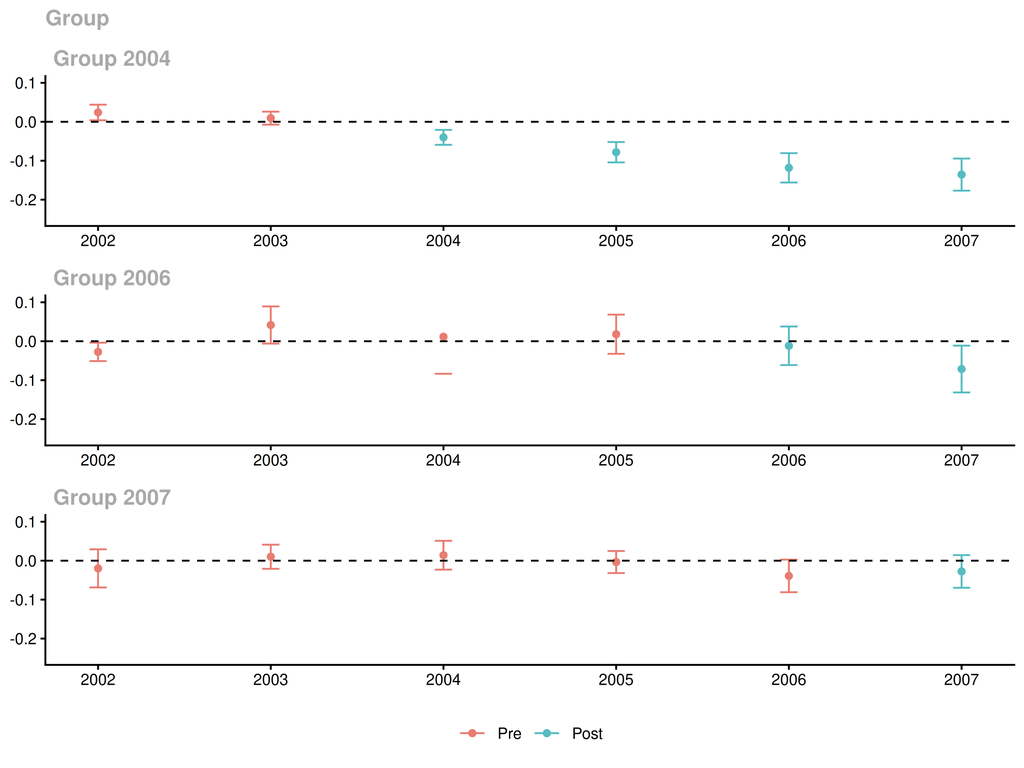

```r
ggdid(cs_u_nyt$gt, ylim = c(-.25, .1))
```

### 4.4.2 Never-treated

```r
# Set control_group to "nevertreated"
cs_u_nt <- run_cs(df, control_group = "nevertreated")
comparison_table(res_u, cs_u_nt,
  "Cohort-specific effects and event study, unconditional case. Control group: never-treated (paper Table A.5)")
```

Cohort-specific effects and event study, unconditional case. Control group: never-treated (paper Table A.5)

|  | MCP ATT | MCP s.e. (bootstrap) | DiD ATT | DiD s.e. |
| --- | --- | --- | --- | --- |
| g = 2004 | -0.0814 | 0.0085 | -0.0913 | 0.0119 |
| g = 2006 | -0.0146 | 0.0101 | -0.0473 | 0.0197 |
| g = 2007 | -0.0454 | 0.0099 | -0.0276 | 0.0162 |
| e = 0 | -0.0216 | 0.0061 | -0.0272 | 0.0102 |
| e = 1 | -0.0533 | 0.0088 | -0.0711 | 0.0153 |
| e = 2 | -0.1065 | 0.0113 | -0.1253 | 0.0165 |
| e = 3 | -0.1224 | 0.0142 | -0.1356 | 0.0167 |

```r
plot_mcp_group(att_pp_u)
```

[output not shown]

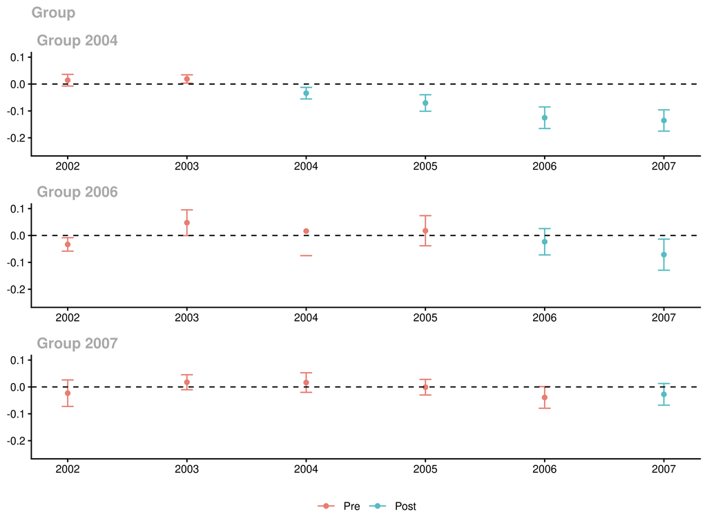

```r
ggdid(cs_u_nt$gt, ylim = c(-.25, .1))
```

# 5 Conditional case (with covariates)

## 5.1 MCP estimation with covariates

```r
# CS benchmark sample: full panel, rows with missing covariates dropped
df_c <- df |>
  drop_na(all_of(cov_vars))

mats_c <- build_panel_matrices(df_c, cov_names = cov_vars)

res_c <- run_mcp(mats_c, X = mats_c$X, Z = mats_c$Z, B = B)
sprintf("MCP-C | RMSE = %.4f | B = %d | never-treated states resampled = %d",
        res_c$rmse, res_c$B, res_c$n_states)
```

```
## [1] "MCP-C | RMSE = 0.1636 | B = 200 | never-treated states resampled = 16"
```

```r
# Extra step of tuning: two regularization parameters (lambda_L and lambda_H) to select by CV
res_c$lambdas[grep("^best", names(res_c$lambdas))]
```

```
## best_lambda_L best_lambda_H
##  8.009849e-06  3.326933e-06
```

## 5.2 ATT aggregation

```r
knitr::kable(res_c$ci$gt |>
               mutate(event_time = year - first_treat) |>
               select(first_treat, year, event_time, att, boot_se,
                      ci_lo, ci_hi, sig),
             digits = 4,
             caption = "MCP-C: cohort-year ATT, bootstrap s.e. and 95% CIs")
```

MCP-C: cohort-year ATT, bootstrap s.e. and 95% CIs

| first_treat | year | event_time | att | boot_se | ci_lo | ci_hi | sig |
| --- | --- | --- | --- | --- | --- | --- | --- |
| 2004 | 2004 | 0 | -0.0289 | 0.0081 | -0.0502 | -0.0179 | TRUE |
| 2004 | 2005 | 1 | -0.0659 | 0.0084 | -0.0836 | -0.0511 | TRUE |
| 2004 | 2006 | 2 | -0.1059 | 0.0114 | -0.1279 | -0.0847 | TRUE |
| 2004 | 2007 | 3 | -0.1220 | 0.0159 | -0.1505 | -0.0890 | TRUE |
| 2006 | 2006 | 0 | 0.0111 | 0.0088 | -0.0041 | 0.0292 | FALSE |
| 2006 | 2007 | 1 | -0.0392 | 0.0139 | -0.0628 | -0.0106 | TRUE |
| 2007 | 2007 | 0 | -0.0458 | 0.0116 | -0.0655 | -0.0216 | TRUE |

## 5.3 Group-time plot (MCP)

```r
att_pp_c <- build_att_pre_post(res_c, mats_c)
plot_mcp_group(att_pp_c)
```

[output not shown]

## 5.4 Comparison with staggered DiD

CS estimated with the reconstructed time-varying covariates, on the full panel.

### 5.4.1 Not-yet-treated (benchmark)

```r
cs_c_nyt <- run_cs(df_c,
                   control_group = "notyettreated",
                   xformla = ~ white_covs + pop_covs + pov_covs + medinc_covs)
comparison_table(res_c, cs_c_nyt,
  "Cohort-specific effects and event study, conditional case. Control group: not-yet-treated (paper Table 2)")
```

Cohort-specific effects and event study, conditional case. Control group: not-yet-treated (paper Table 2)

|  | MCP ATT | MCP s.e. (bootstrap) | DiD ATT | DiD s.e. |
| --- | --- | --- | --- | --- |
| g = 2004 | -0.0807 | 0.0092 | -0.0949 | 0.0100 |
| g = 2006 | -0.0141 | 0.0109 | -0.0403 | 0.0203 |
| g = 2007 | -0.0458 | 0.0116 | -0.0301 | 0.0166 |
| e = 0 | -0.0212 | 0.0069 | -0.0257 | 0.0098 |
| e = 1 | -0.0526 | 0.0098 | -0.0752 | 0.0159 |
| e = 2 | -0.1059 | 0.0114 | -0.1177 | 0.0158 |
| e = 3 | -0.1220 | 0.0159 | -0.1414 | 0.0179 |

```r
plot_mcp_group(att_pp_c)
```

[output not shown]

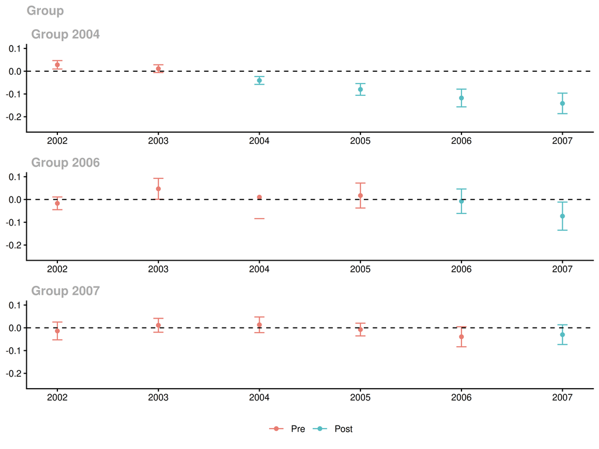

```r
ggdid(cs_c_nyt$gt, ylim = c(-.25, .1))
```

### 5.4.2 Never-treated

```r
cs_c_nt <- run_cs(df_c,
                  control_group = "nevertreated",
                  xformla = ~ white_covs + pop_covs + pov_covs + medinc_covs)
comparison_table(res_c, cs_c_nt,
  "Cohort-specific effects and event study, conditional case. Control group: never-treated (paper Table A.3)")
```

Cohort-specific effects and event study, conditional case. Control group: never-treated (paper Table A.3)

|  | MCP ATT | MCP s.e. (bootstrap) | DiD ATT | DiD s.e. |
| --- | --- | --- | --- | --- |
| g = 2004 | -0.0807 | 0.0092 | -0.0950 | 0.0112 |
| g = 2006 | -0.0141 | 0.0109 | -0.0469 | 0.0216 |
| g = 2007 | -0.0458 | 0.0116 | -0.0301 | 0.0166 |
| e = 0 | -0.0212 | 0.0069 | -0.0283 | 0.0110 |
| e = 1 | -0.0526 | 0.0098 | -0.0739 | 0.0170 |
| e = 2 | -0.1059 | 0.0114 | -0.1285 | 0.0153 |
| e = 3 | -0.1220 | 0.0159 | -0.1414 | 0.0179 |

```r
plot_mcp_group(att_pp_c)
```

[output not shown]

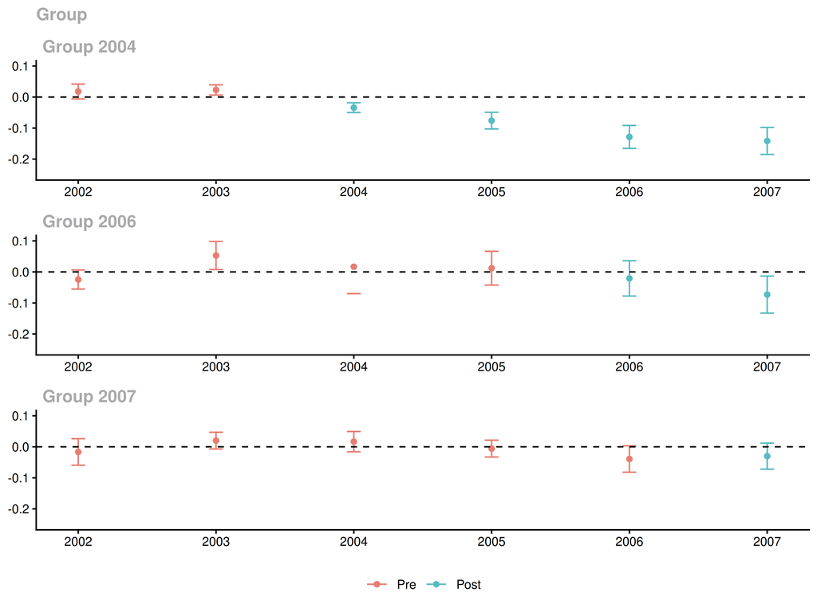

```r
ggdid(cs_c_nt$gt, ylim = c(-.25, .1))
```

# 6 Implementation details

This section reports the tuning, convergence and bootstrap settings. Everything below is computed from the fitted objects at knit time.

**Software.** MCP is estimated with the `MCPanel` package (version reported below and in the session info). Unit and time fixed effects are estimated without regularization (`to_estimate_u = to_estimate_v = 1`), consistent with eq. (3) of the paper.

Note that, in our applications, the best lambda is identified at the first CV round and stays the same across folds.

**Bootstrap.** $B$ state-cluster resamples of the never-treated states, with treated counties held fixed in every draw. Each draw is refitted at the full-sample $\lambda$ (`mcnnm_fit` / `mcnnm_wc_fit`), so the intervals are conditional on the full-sample tuning and capture sampling uncertainty on the control side only. Standard errors are the standard deviation of the draws; intervals are the $\alpha/2$ and $1-\alpha/2$ percentiles.

```r
tibble::tibble(
  component = c("R", "MCPanel", "did", "seed", "bootstrap B"),
  value     = c(paste(R.version$major, R.version$minor, sep = "."),
                as.character(utils::packageVersion("MCPanel")),
                as.character(utils::packageVersion("did")),
                as.character(SEED), as.character(B))
) |>
  knitr::kable(caption = "Software versions and settings")
```

Software versions and settings

| component | value |
| --- | --- |
| R | 4.3.3 |
| MCPanel | 0.0 |
| did | 2.5.1 |
| seed | 2024 |
| bootstrap B | 200 |

```r
# Regularization parameters selected by CV on the full sample, reused in every bootstrap refit
best_lam <- function(lams) lams[grep("^best", names(lams))]
bind_rows(
  tibble::tibble(fit = "MCP-U", parameter = names(best_lam(res_u$lambdas)),
                 value = unname(best_lam(res_u$lambdas))),
  tibble::tibble(fit = "MCP-C", parameter = names(best_lam(res_c$lambdas)),
                 value = unname(best_lam(res_c$lambdas)))
) |>
  knitr::kable(digits = 8,
               caption = "Regularization parameters selected by CV (full sample)")
```

Regularization parameters selected by CV (full sample)

| fit | parameter | value |
| --- | --- | --- |
| MCP-U | best_lambda | 0.00e+00 |
| MCP-C | best_lambda_L | 8.01e-06 |
| MCP-C | best_lambda_H | 3.33e-06 |

```r
# Bootstrap diagnostics: every cell should have B draws
boot_diag <- function(res, label) {
  tibble::tibble(
    fit              = label,
    B                = res$B,
    resampled_states = res$n_states,
    min_draws_cell   = min(count(res$boot$gt, first_treat, year)$n),
    mean_boot_se_gt  = mean(res$ci$gt$boot_se)
  )
}
bind_rows(boot_diag(res_u, "MCP-U"), boot_diag(res_c, "MCP-C")) |>
  knitr::kable(digits = 4, caption = "Bootstrap diagnostics")
```

Bootstrap diagnostics

| fit | B | resampled_states | min_draws_cell | mean_boot_se_gt |
| --- | --- | --- | --- | --- |
| MCP-U | 200 | 16 | 200 | 0.0100 |
| MCP-C | 200 | 16 | 200 | 0.0112 |

```r
# Effective rank of L_hat implied by the selected penalty
eff_rank <- function(L) sum(svd(L)$d > max(svd(L)$d) * 1e-8)
tibble::tibble(fit = c("MCP-U", "MCP-C"),
               effective_rank = c(eff_rank(res_u$fit$L), eff_rank(res_c$fit$L))) |>
  knitr::kable(caption = "Effective rank of the estimated low-rank component")
```

Effective rank of the estimated low-rank component

| fit | effective_rank |
| --- | --- |
| MCP-U | 6 |
| MCP-C | 6 |

# 7 Falsification: parallel trends via MCP

Following Section 4.1 and Appendix A.4.1 of the paper. We take $\hat Y_{it}(0)$ from the MCP estimate — which coincides with the observed outcome wherever $W_{it}=0$ — compute its first difference $dY_{it}(0)$, and regress it on a cohort dummy $G_g$ over the window $t \ge \tau_g$:

- **Never-treated test (eq. 6)**: $G_g = 1$ for units first treated in $g$, $0$ for never-treated units; other cohorts excluded.
- **Not-yet-treated test (eq. 7)**: $G_g = 1$ for units first treated in $g$, $0$ for never-treated units and cohorts treated after $g$. For the last cohort (2007) the not-yet-treated group coincides with the never-treated, so the cell is empty as in Table 3.

The conditional version (Table 3) includes the covariates in the regression; the unconditional version (Table A.6) does not. The test uses the full-sample MCP fit (b = 0).

```r
pt_falsification <- function(fit, mats, df_long = NULL, cov_names = NULL) {

  # Imputed untreated-outcome matrix: observed where W=0, imputed where W=1
  Y0  <- mats$Y * mats$mask + fit$Mhat * (1 - mats$mask)
  dY0 <- Y0[, -1, drop = FALSE] - Y0[, -ncol(Y0), drop = FALSE]
  colnames(dY0) <- mats$years[-1]

  long <- tibble::tibble(
    countyreal  = rep(mats$unit_order, each = ncol(dY0)),
    year        = rep(as.integer(colnames(dY0)), nrow(dY0)),
    first_treat = rep(mats$first_treat, each = ncol(dY0)),
    dy          = as.vector(t(dY0))
  )

  if (!is.null(cov_names)) {
    long <- long |>
      left_join(df_long |> select(countyreal, year, all_of(cov_names)),
                by = c("countyreal", "year"))
  }

  cohorts <- sort(unique(long$first_treat[long$first_treat > 0]))

  run_one <- function(g, control) {
    keep <- if (control == "never") {
      long$first_treat %in% c(0, g)
    } else {
      long$first_treat == g | long$first_treat == 0 | long$first_treat > g
    }
    # NYT is degenerate (== never-treated) for the last cohort
    if (control == "nyt" && !any(long$first_treat > g)) return(NULL)

    dat <- long[keep & long$year >= g, , drop = FALSE] |>
      mutate(G = as.integer(first_treat == g)) |>
      drop_na()

    f <- if (is.null(cov_names)) dy ~ G else reformulate(c("G", cov_names), "dy")
    co <- summary(lm(f, data = dat))$coefficients["G", ]

    tibble::tibble(cohort = g, control = control,
                   coef = co[["Estimate"]], se = co[["Std. Error"]])
  }

  bind_rows(lapply(cohorts, \(g)
    bind_rows(run_one(g, "never"), run_one(g, "nyt")))) |>
    mutate(cell = sprintf("%.3f (%.3f)", coef, se)) |>
    select(cohort, control, cell) |>
    pivot_wider(names_from = control, values_from = cell) |>
    rename(`Never-treated` = never, `Not-yet-treated` = nyt)
}
```

```r
pt_falsification(res_c$fit, mats_c, df_c, cov_names = cov_vars) |>
  knitr::kable(caption = "Testing the parallel trends assumption, conditional case (paper Table 3). Coefficient (s.e.).")
```

Testing the parallel trends assumption, conditional case (paper Table 3). Coefficient (s.e.).

| cohort | Never-treated | Not-yet-treated |
| --- | --- | --- |
| 2004 | -0.006 (0.008) | -0.004 (0.008) |
| 2006 | -0.018 (0.008) | -0.013 (0.007) |
| 2007 | 0.015 (0.007) | NA |

```r
pt_falsification(res_u$fit, mats) |>
  knitr::kable(caption = "Testing the parallel trends assumption, unconditional case (paper Table A.6). Coefficient (s.e.).")
```

Testing the parallel trends assumption, unconditional case (paper Table A.6). Coefficient (s.e.).

| cohort | Never-treated | Not-yet-treated |
| --- | --- | --- |
| 2004 | -0.003 (0.008) | -0.003 (0.008) |
| 2006 | -0.016 (0.008) | -0.013 (0.007) |
| 2007 | 0.018 (0.007) | NA |

[session information not shown]